# Calidad de vida

Ca gastrico

4/15/2024

En este documento consideramos los siguientes datos:

```r
Auto2 <- read_excel("cagastrico3.xlsx")
```

## El código

A continuacion `prcomp()` es una funcion que realiza análisis de componentes principales components y reemplaza a `pca()` en otros codigos. El análisis de componentes principales es una técnica para transformar las variables originales (generalmente correlacionadas entre si) por variables nuevas no correlacionadas. Estas variables nuevas son denominadas o componentes principales.

- Cada componente es una combinacion lineal de todas las variables. Es decir, cada componente contiene informacion de cada una de las variables originales:

$$C_{i} = a_{i1}x_{1} + a_{i2}x_{2} + \dots + a_{ip}x_{p}$$

La cantidad de informacion explicada o contenida por cada componente se mide en funcion de su varianza.

Esta tecnica muestra que es posible construir variables nuevas a partir de variables originales. Este es precisamente el concepto o defincion de **variable latente**.

```r
calidad_comp <- prcomp(Auto2)
str(calidad_comp)
```

```
## List of 5
##  $ sdev    : num [1:46] 5.86 2.51 2.22 2.12 2.01 ...
##  $ rotation: num [1:46, 1:46] -0.18 -0.136 -0.184 -0.17 -0.101 ...
##   ..- attr(*, "dimnames")=List of 2
##   .. ..$ : chr [1:46] "GP1" "GP2" "GP3" "GP4" ...
##   .. ..$ : chr [1:46] "PC1" "PC2" "PC3" "PC4" ...
##  $ center  : Named num [1:46] 1.309 0.877 0.914 1.16 0.605 ...
##   ..- attr(*, "names")= chr [1:46] "GP1" "GP2" "GP3" "GP4" ...
##  $ scale   : logi FALSE
##  $ x       : num [1:81, 1:46] -3.615 -14.388 4.607 6.682 0.355 ...
##   ..- attr(*, "dimnames")=List of 2
##   .. ..$ : NULL
##   .. ..$ : chr [1:46] "PC1" "PC2" "PC3" "PC4" ...
##  - attr(*, "class")= chr "prcomp"
```

## Los componentes

```r
summary(calidad_comp)
```

```
## Importance of components:
##                           PC1     PC2    PC3     PC4     PC5     PC6     PC7
## Standard deviation     5.8638 2.50800 2.2171 2.11539 2.01400 1.88695 1.73747
## Proportion of Variance 0.3609 0.06602 0.0516 0.04697 0.04258 0.03737 0.03169
## Cumulative Proportion  0.3609 0.42693 0.4785 0.52550 0.56807 0.60545 0.63713
##                            PC8     PC9    PC10    PC11    PC12    PC13    PC14
## Standard deviation     1.67731 1.61179 1.53768 1.47895 1.43280 1.37019 1.31750
## Proportion of Variance 0.02953 0.02727 0.02482 0.02296 0.02155 0.01971 0.01822
## Cumulative Proportion  0.66666 0.69393 0.71875 0.74171 0.76326 0.78296 0.80118
##                          PC15    PC16    PC17    PC18    PC19    PC20    PC21
## Standard deviation     1.2801 1.24526 1.20624 1.16207 1.08858 1.06399 1.02336
## Proportion of Variance 0.0172 0.01628 0.01527 0.01417 0.01244 0.01188 0.01099
## Cumulative Proportion  0.8184 0.83466 0.84993 0.86411 0.87654 0.88843 0.89942
##                          PC22    PC23    PC24    PC25    PC26    PC27    PC28
## Standard deviation     0.9810 0.93274 0.90741 0.88425 0.82417 0.79851 0.76509
## Proportion of Variance 0.0101 0.00913 0.00864 0.00821 0.00713 0.00669 0.00614
## Cumulative Proportion  0.9095 0.91865 0.92729 0.93550 0.94263 0.94932 0.95547
##                           PC29    PC30    PC31    PC32    PC33    PC34    PC35
## Standard deviation     0.72488 0.70632 0.65842 0.61405 0.58398 0.54029 0.53776
## Proportion of Variance 0.00552 0.00524 0.00455 0.00396 0.00358 0.00306 0.00304
## Cumulative Proportion  0.96098 0.96622 0.97077 0.97473 0.97831 0.98137 0.98441
##                           PC36    PC37    PC38    PC39    PC40   PC41    PC42
## Standard deviation     0.48551 0.47531 0.43805 0.41285 0.37928 0.3514 0.33377
## Proportion of Variance 0.00247 0.00237 0.00201 0.00179 0.00151 0.0013 0.00117
## Cumulative Proportion  0.98688 0.98925 0.99127 0.99306 0.99457 0.9959 0.99703
##                           PC43    PC44    PC45    PC46
## Standard deviation     0.31952 0.27325 0.24727 0.21193
## Proportion of Variance 0.00107 0.00078 0.00064 0.00047
## Cumulative Proportion  0.99810 0.99889 0.99953 1.00000
```

## La imagen

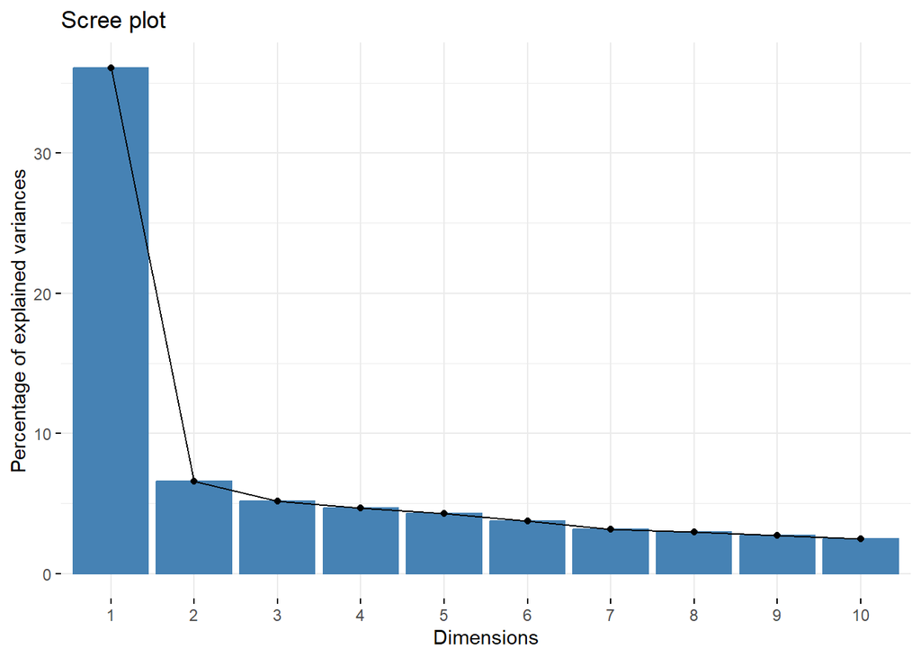

```r
fviz_eig(calidad_comp)
```

### Tarea

Realizar el anterior proceso con las variables centradas y estandarizadas:

```r
calidad_comp2 <- prcomp(Auto2, center = T, scale. = T)
str(calidad_comp2)
```

```
## List of 5
##  $ sdev    : num [1:46] 4.04 1.67 1.55 1.4 1.33 ...
##  $ rotation: num [1:46, 1:46] -0.166 -0.152 -0.178 -0.162 -0.114 ...
##   ..- attr(*, "dimnames")=List of 2
##   .. ..$ : chr [1:46] "GP1" "GP2" "GP3" "GP4" ...
##   .. ..$ : chr [1:46] "PC1" "PC2" "PC3" "PC4" ...
##  $ center  : Named num [1:46] 1.309 0.877 0.914 1.16 0.605 ...
##   ..- attr(*, "names")= chr [1:46] "GP1" "GP2" "GP3" "GP4" ...
##  $ scale   : Named num [1:46] 1.56 1.3 1.51 1.51 1.28 ...
##   ..- attr(*, "names")= chr [1:46] "GP1" "GP2" "GP3" "GP4" ...
##  $ x       : num [1:81, 1:46] -2.5905 -11.1125 3.3201 4.264 0.0158 ...
##   ..- attr(*, "dimnames")=List of 2
##   .. ..$ : NULL
##   .. ..$ : chr [1:46] "PC1" "PC2" "PC3" "PC4" ...
##  - attr(*, "class")= chr "prcomp"
```

## Grafico

En esta imagen observamos la distribucion de los sujetos de investigacion en relacion a las dimensiones o componente 1 y 2

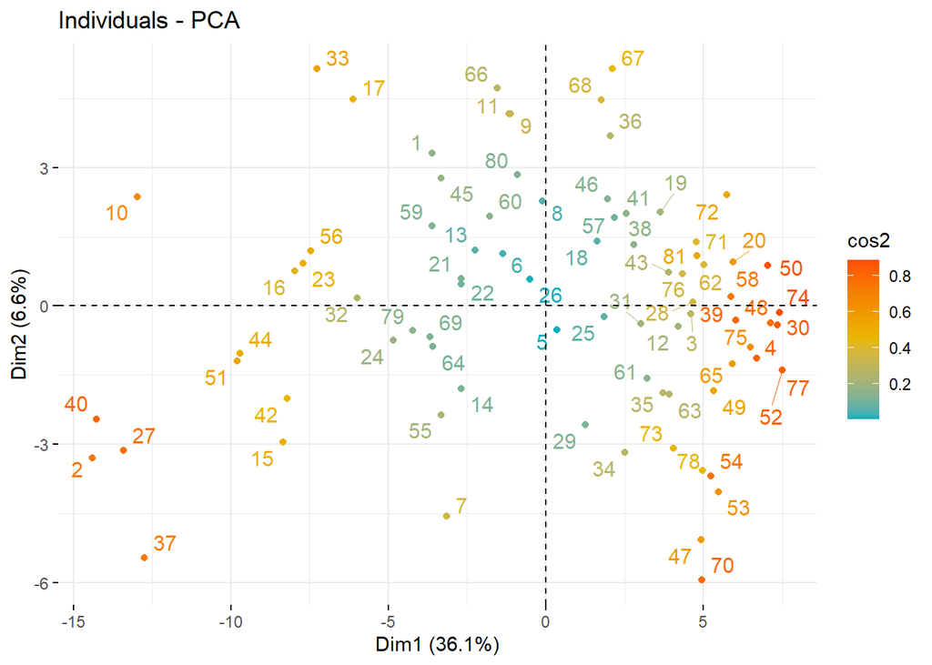

```r
fviz_pca_ind(calidad_comp,
             col.ind = "cos2", # Color by the quality of representation
             gradient.cols = c("#00AFBB", "#E7B800", "#FC4E07"),
             repel = TRUE     # Avoid text overlapping
             )
```

## Grafico

Grafico de variables en relacion a las dimensiones o componente 1 y 2

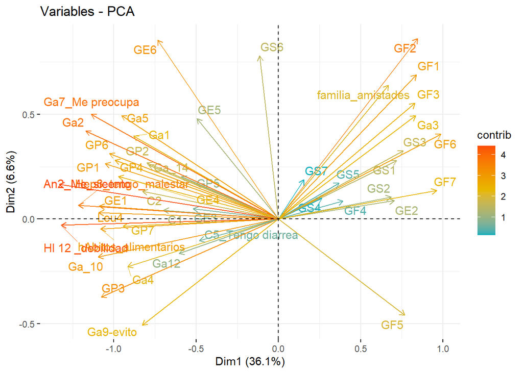

```r
fviz_pca_var(calidad_comp,
             col.var = "contrib", # Color by contributions to the PC
             gradient.cols = c("#00AFBB", "#E7B800", "#FC4E07"),
             repel = TRUE     # Avoid text overlapping
             )
```

## Grafica Graficas sujetos y pacientes

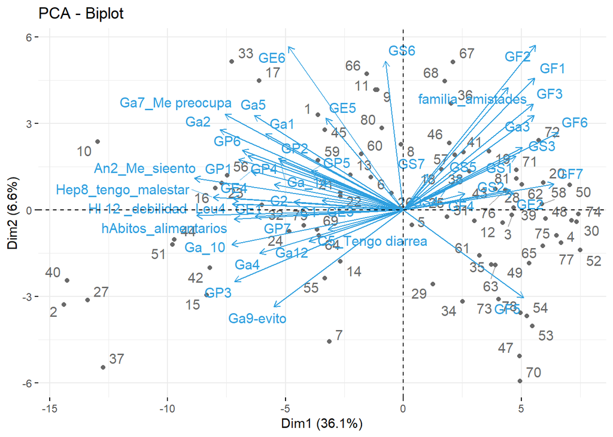

```r
fviz_pca_biplot(calidad_comp, repel = TRUE,
                col.var = "#2E9FDF", # Variables color
                col.ind = "#696969"  # Individuals color
                )
```

```r
calidad_clust_completo <- hclust(dist(calidad_comp$x[,1:4]),
                                 method = "complete")
```

```r
dendro_data_k <- function(hc, k) {

  hcdata    <-  ggdendro::dendro_data(hc, type = "rectangle")
  seg       <-  hcdata$segments
  labclust  <-  cutree(hc, k)[hc$order]
  segclust  <-  rep(0L, nrow(seg))
  heights   <-  sort(hc$height, decreasing = TRUE)
  height    <-  mean(c(heights[k], heights[k - 1L]), na.rm = TRUE)

  for (i in 1:k) {
    xi      <-  hcdata$labels$x[labclust == i]
    idx1    <-  seg$x    >= min(xi) & seg$x    <= max(xi)
    idx2    <-  seg$xend >= min(xi) & seg$xend <= max(xi)
    idx3    <-  seg$yend < height
    idx     <-  idx1 & idx2 & idx3
    segclust[idx] <- i
  }

  idx                    <-  which(segclust == 0L)
  segclust[idx]          <-  segclust[idx + 1L]
  hcdata$segments$clust  <-  segclust
  hcdata$segments$line   <-  as.integer(segclust < 1L)
  hcdata$labels$clust    <-  labclust

  hcdata
}

set_labels_params <- function(nbLabels,
                              direction = c("tb", "bt", "lr", "rl"),
                              fan       = FALSE) {
  if (fan) {
    angle       <-  360 / nbLabels * 1:nbLabels + 90
    idx         <-  angle >= 90 & angle <= 270
    angle[idx]  <-  angle[idx] + 180
    hjust       <-  rep(0, nbLabels)
    hjust[idx]  <-  1
  } else {
    angle       <-  rep(0, nbLabels)
    hjust       <-  0
    if (direction %in% c("tb", "bt")) { angle <- angle + 45 }
    if (direction %in% c("tb", "rl")) { hjust <- 1 }
  }
  list(angle = angle, hjust = hjust, vjust = 0.5)
}

plot_ggdendro <- function(hcdata,
                          direction   = c("lr", "rl", "tb", "bt"),
                          fan         = FALSE,
                          scale.color = NULL,
                          branch.size = 1,
                          label.size  = 3,
                          nudge.label = 0.01,
                          expand.y    = 0.1) {

  direction <- match.arg(direction) # if fan = FALSE
  ybreaks   <- pretty(segment(hcdata)$y, n = 5)
  ymax      <- max(segment(hcdata)$y)

  ## branches
  p <- ggplot() +
    geom_segment(data         =  segment(hcdata),
                 aes(x        =  x,
                     y        =  y,
                     xend     =  xend,
                     yend     =  yend,
                     linetype =  factor(line),
                     colour   =  factor(clust)),
                 lineend      =  "round",
                 show.legend  =  FALSE,
                 size         =  branch.size)

  ## orientation
  if (fan) {
    p <- p +
      coord_polar(direction = -1) +
      scale_x_continuous(breaks = NULL,
                         limits = c(0, nrow(label(hcdata)))) +
      scale_y_reverse(breaks = ybreaks)
  } else {
    p <- p + scale_x_continuous(breaks = NULL)
    if (direction %in% c("rl", "lr")) {
      p <- p + coord_flip()
    }
    if (direction %in% c("bt", "lr")) {
      p <- p + scale_y_reverse(breaks = ybreaks)
    } else {
      p <- p + scale_y_continuous(breaks = ybreaks)
      nudge.label <- -(nudge.label)
    }
  }

  # labels
  labelParams <- set_labels_params(nrow(hcdata$labels), direction, fan)
  hcdata$labels$angle <- labelParams$angle

  p <- p +
    geom_text(data        =  label(hcdata),
              aes(x       =  x,
                  y       =  y,
                  label   =  label,
                  colour  =  factor(clust),
                  angle   =  angle),
              vjust       =  labelParams$vjust,
              hjust       =  labelParams$hjust,
              nudge_y     =  ymax * nudge.label,
              size        =  label.size,
              show.legend =  FALSE)

  # colors and limits
  if (!is.null(scale.color)) {
    p <- p + scale_color_manual(values = scale.color)
  }

  ylim <- -round(ymax * expand.y, 1)
  p    <- p + expand_limits(y = ylim)

  p
}
```

```r
hcdata_calidad <- dendro_data_k(calidad_clust_completo, 10)
```

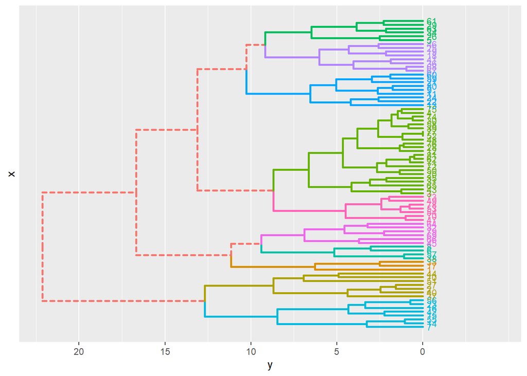

```r
p <- plot_ggdendro(hcdata_calidad,
                   direction   = "lr",
                   expand.y    = 0.2)
p
```

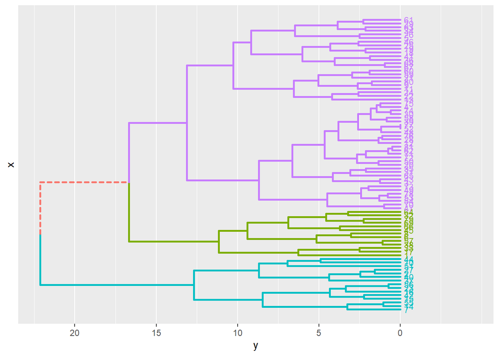

```r
hcdata_calidad <- dendro_data_k(calidad_clust_completo, 3)

p <- plot_ggdendro(hcdata_calidad,
                   direction   = "lr",
                   expand.y    = 0.2)
p
```

```r
Autoimagen <- read_excel("Autoimagenfinal.xlsx")
```

```r
Autoimagen$Edad = as.numeric(Autoimagen$Edad)
Autoimagen$SGSSS = factor(Autoimagen$SGSSS)
Autoimagen$Residencia = factor(Autoimagen$Residencia)
Autoimagen$Departamento_Atencion = factor(Autoimagen$Departamento_Atencion)
Autoimagen$Descripcion_Diagnostico = factor(Autoimagen$Descripcion_Diagnostico)
Autoimagen$Tipo_Paciente = factor(Autoimagen$Tipo_Diagnostico)
Autoimagen$ano_DX = factor(Autoimagen$ano_DX)
Autoimagen$Remision = factor(Autoimagen$Remision)
Autoimagen$Tipo_Diagnostico = factor(Autoimagen$Tipo_Diagnostico)
Autoimagen$Histologia = factor(Autoimagen$Histologia)
Autoimagen$Diferenciacion = factor(Autoimagen$Diferenciacion)
Autoimagen$Estado = factor(Autoimagen$Estado)
Autoimagen$HER2 = factor(Autoimagen$HER2)
Autoimagen$Objetivo_medico = factor(Autoimagen$Objetivo_medico)
Autoimagen$Otro_Primario = factor(Autoimagen$Otro_Primario)
Autoimagen$Quimioterapia = factor(Autoimagen$Quimioterapia)
Autoimagen$Cirugia = factor(Autoimagen$Cirugia)
Autoimagen$Radioterapia = factor(Autoimagen$Radioterapia)
Autoimagen$Cirugia_Reconstructiva = factor(Autoimagen$Cirugia_Reconstructiva)
Autoimagen$Paliativo = factor(Autoimagen$Paliativo)
Autoimagen$Nutricion = factor(Autoimagen$Nutricion)
Autoimagen$Imagen = factor(Autoimagen$Imagen)
Autoimagen$Imagen2 = factor(Autoimagen$Imagen2)
```

```r
set.seed(123)
index <- createDataPartition(Autoimagen$Imagen2, p = 0.8, list = F)

Autoimagen_train <- Autoimagen[index, ]
Autoimagen_test <- Autoimagen[-index, ]
```

Ahora procedemos a definir la validacion cruzada.

# Validacion cruzada

La validacion cruzada es un proceso que nos permite encontrar los valores optimos de los hiperparametros de los algoritmos propuestos. K-fold cross-validation es una tecnica estandar y eficiente, donde k representa el numero de folds o particiones realizados sobre los datos de entrenamiento.

Lo mas estandar es utilizar 10 folds y una busqueda aleatorio sobre el espacio hiperparametrico:

```r
control <- trainControl(method = 'cv', number = 10, search = 'random')
```

# Modelos

## Regresion Logistica

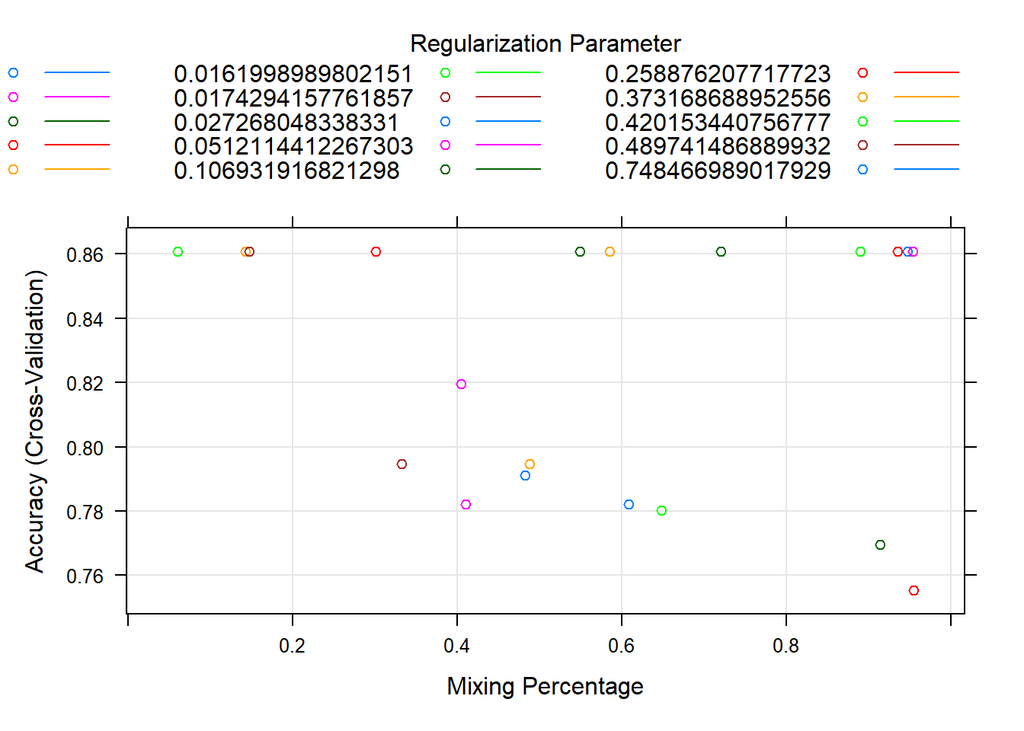

```r
logistic_model <- train(Imagen2 ~ Edad + SGSSS + Descripcion_Diagnostico +
                          Tipo_Paciente + Tipo_Diagnostico + Histologia +
                          Diferenciacion + Estado + HER2 + Objetivo_medico +
                          Otro_Primario + Quimioterapia + Cirugia + Radioterapia +
                          Paliativo + Nutricion,
                        data = Autoimagen_train,
                        method = 'glmnet',
                        search = 'random',
                        tuneLength = 20,
                        trControl = control)

plot(logistic_model)
```

### Predicciones

```r
logistic_model_pred <- predict(logistic_model, Autoimagen_test, type = 'raw')

confusionMatrix(Autoimagen_test$Imagen2, logistic_model_pred)
```

```
## Confusion Matrix and Statistics
##
##           Reference
## Prediction BUENA NO
##      BUENA    15  0
##      NO        2  0
##
##                Accuracy : 0.8824
##                  95% CI : (0.6356, 0.9854)
##     No Information Rate : 1
##     P-Value [Acc > NIR] : 1.0000
##
##                   Kappa : 0
##
##  Mcnemar's Test P-Value : 0.4795
##
##             Sensitivity : 0.8824
##             Specificity :     NA
##          Pos Pred Value :     NA
##          Neg Pred Value :     NA
##              Prevalence : 1.0000
##          Detection Rate : 0.8824
##    Detection Prevalence : 0.8824
##       Balanced Accuracy :     NA
##
##        'Positive' Class : BUENA
##
```

La especificidad del modelo es inaceptable.

## Random Ferns

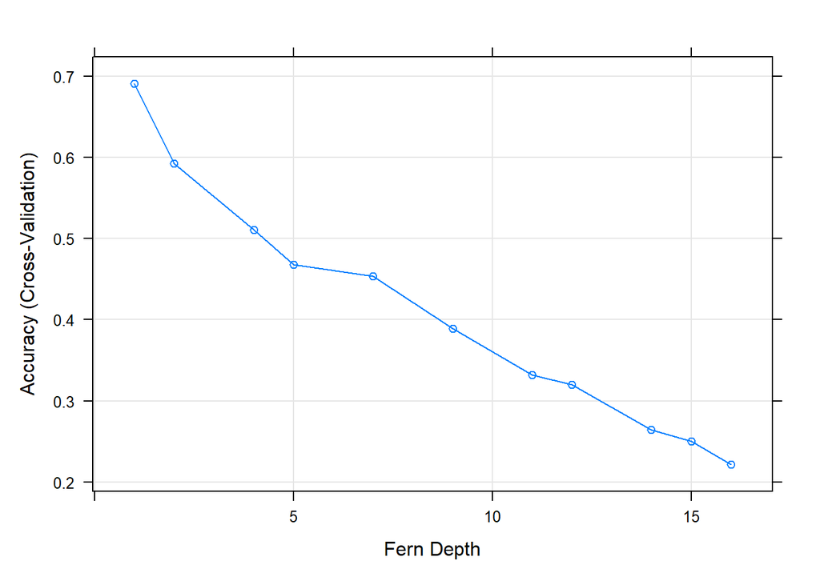

```r
rFerns_model <- train(Imagen2 ~ Edad + SGSSS + Descripcion_Diagnostico +
                          Tipo_Paciente + Tipo_Diagnostico + Histologia +
                          Diferenciacion + Estado + HER2 + Objetivo_medico +
                          Otro_Primario + Quimioterapia + Cirugia + Radioterapia +
                          Paliativo + Nutricion,
                      data = Autoimagen_train,
                      method = 'rFerns',
                      metric = 'Accuracy',
                      search = 'random',
                      tuneLength = 20,
                      trControl = control)

plot(rFerns_model)
```

### Predicciones

```r
rFerns_model_pred <- predict(rFerns_model, Autoimagen_test, type = 'raw')

confusionMatrix(Autoimagen_test$Imagen2, rFerns_model_pred)
```

```
## Confusion Matrix and Statistics
##
##           Reference
## Prediction BUENA NO
##      BUENA     7  8
##      NO        1  1
##
##                Accuracy : 0.4706
##                  95% CI : (0.2298, 0.7219)
##     No Information Rate : 0.5294
##     P-Value [Acc > NIR] : 0.7671
##
##                   Kappa : -0.0132
##
##  Mcnemar's Test P-Value : 0.0455
##
##             Sensitivity : 0.8750
##             Specificity : 0.1111
##          Pos Pred Value : 0.4667
##          Neg Pred Value : 0.5000
##              Prevalence : 0.4706
##          Detection Rate : 0.4118
##    Detection Prevalence : 0.8824
##       Balanced Accuracy : 0.4931
##
##        'Positive' Class : BUENA
##
```

## Support Vector Machines (Linear)

```r
SVM_Linear_model <- train(Imagen2 ~ Edad + SGSSS +
                          Tipo_Paciente + Tipo_Diagnostico +
                          Estado + HER2 + Objetivo_medico +
                          Quimioterapia + Cirugia + Radioterapia +
                          Paliativo ,
                          data = Autoimagen_train,
                          method = 'lssvmLinear',
                          metric = 'Accuracy',
                          search = 'random',
                          tuneLength = 20,
                          trControl = control)

plot(SVM_Linear_model)
```

[output not shown]

### Predicciones

```r
SVM_Linear_model_pred <- predict(SVM_Linear_model, Autoimagen_test, type = 'raw')

confusionMatrix(Autoimagen_test$Imagen2, SVM_Linear_model_pred)
```

[output not shown]